# version 2

# Title: Students Exam Scores

# keyword: DataFrame, random,rows, column, del(delete),drop

# Objectives

This dataset includes scores from three test scores of students at a (fictional) public school and a variety of personal and socio-economic factors that may have interaction effects upon them.

To understand how the student's performance (test scores) is affected by the other variables (Gender, Ethnicity, Lunch, Test preparation course).

# Import:

- The Statement to make sure that the given module is ready to be called, as numpy,pandas,random

```python
import numpy as np
import pandas as pd
from pandas import Series,DataFrame
import random

# These are the plotting modules adn libraries we'll use:
import matplotlib as mpl
import matplotlib.pyplot as plt
import seaborn as sns
# Command so that plots appear in the iPython Notebook
%matplotlib inline

# Import the stats library from numpy
from scipy import stats
```

# Reading data:

- pandas provide the read*csv() function to read data stored as a csv file into a pandas DataFrame. pandas supports many different file formats or data sources out of the box (csv, excel, sql, json, parquet, …), each of them with the prefix read**.

```python
#Read file
student_frame= pd.read_csv("Students_Exam_Scores.csv")
```

```python
student_frame
```

|  | Unnamed: 0 | Gender | EthnicGroup | ParentEduc | LunchType | TestPrep | MathScore | ReadingScore | WritingScore |
| --- | --- | --- | --- | --- | --- | --- | --- | --- | --- |
| 0 | 0 | female | group B | bachelor's degree | standard | none | 72 | 72 | 74 |
| 1 | 1 | female | group C | some college | standard | completed | 69 | 90 | 88 |
| 2 | 2 | female | group B | master's degree | standard | none | 90 | 95 | 93 |
| 3 | 3 | male | group A | associate's degree | free/reduced | none | 47 | 57 | 44 |
| 4 | 4 | male | group C | some college | standard | none | 76 | 78 | 75 |
| ... | ... | ... | ... | ... | ... | ... | ... | ... | ... |
| 994 | 994 | male | group A | high school | standard | none | 63 | 63 | 62 |
| 995 | 995 | female | group E | master's degree | standard | completed | 88 | 99 | 95 |
| 996 | 996 | male | group C | high school | free/reduced | none | 62 | 55 | 55 |
| 997 | 997 | female | group C | high school | free/reduced | completed | 59 | 71 | 65 |
| 998 | 998 | female | group D | some college | standard | completed | 68 | 78 | 77 |

999 rows × 9 columns

# Data Structure (info,shape):

Here, you can see all the column names, total values and type of the values.

We have 2 types of variables. Numerical variables : which contains number as values Categorical variables : which contains descriptions of groups or things. In this Data set,

Numerical Variables are Math score, Reading score and Writing score.

Categorical Variables are Gender,EthnicGroup, Parental level of education, Lunch and Test preparation course.

```python
#Data structure info
student_frame.info()
```

```
<class 'pandas.core.frame.DataFrame'>
RangeIndex: 999 entries, 0 to 998
Data columns (total 9 columns):
 #   Column        Non-Null Count  Dtype
---  ------        --------------  -----
 0   Unnamed: 0    999 non-null    int64
 1   Gender        999 non-null    object
 2   EthnicGroup   999 non-null    object
 3   ParentEduc    999 non-null    object
 4   LunchType     999 non-null    object
 5   TestPrep      999 non-null    object
 6   MathScore     999 non-null    int64
 7   ReadingScore  999 non-null    int64
 8   WritingScore  999 non-null    int64
dtypes: int64(4), object(5)
memory usage: 70.4+ KB
```

```python
#Data structure shape
student_frame.shape
```

```
(999, 9)
```

# Data manipulation:

- Subsetting(Subsetting a data frame is the process of selecting a set of desired rows and columns from the data frame). Select columns and Filter rows

```python
#column names
student_frame.columns
```

```
Index(['Unnamed: 0', 'Gender', 'EthnicGroup', 'ParentEduc', 'LunchType',
       'TestPrep', 'MathScore', 'ReadingScore', 'WritingScore'],
      dtype='object')
```

```python
#show first 100 rows
student_frame.head(100)
```

|  | Unnamed: 0 | Gender | EthnicGroup | ParentEduc | LunchType | TestPrep | MathScore | ReadingScore | WritingScore |
| --- | --- | --- | --- | --- | --- | --- | --- | --- | --- |
| 0 | 0 | female | group B | bachelor's degree | standard | none | 72 | 72 | 74 |
| 1 | 1 | female | group C | some college | standard | completed | 69 | 90 | 88 |
| 2 | 2 | female | group B | master's degree | standard | none | 90 | 95 | 93 |
| 3 | 3 | male | group A | associate's degree | free/reduced | none | 47 | 57 | 44 |
| 4 | 4 | male | group C | some college | standard | none | 76 | 78 | 75 |
| ... | ... | ... | ... | ... | ... | ... | ... | ... | ... |
| 95 | 95 | male | group C | associate's degree | free/reduced | completed | 78 | 81 | 82 |
| 96 | 96 | male | group B | some high school | standard | completed | 65 | 66 | 62 |
| 97 | 97 | female | group E | some college | standard | completed | 63 | 72 | 70 |
| 98 | 98 | female | group D | some college | free/reduced | none | 58 | 67 | 62 |
| 99 | 99 | female | group D | bachelor's degree | standard | none | 65 | 67 | 62 |

100 rows × 9 columns

```python
#last two rows

student_frame.tail(2)
```

|  | Unnamed: 0 | Gender | EthnicGroup | ParentEduc | LunchType | TestPrep | MathScore | ReadingScore | WritingScore |
| --- | --- | --- | --- | --- | --- | --- | --- | --- | --- |
| 997 | 997 | female | group C | high school | free/reduced | completed | 59 | 71 | 65 |
| 998 | 998 | female | group D | some college | standard | completed | 68 | 78 | 77 |

```python
# retrieve a row through indexing
student_frame.loc[50]
```

```
Unnamed: 0                50
Gender                  male
EthnicGroup          group E
ParentEduc      some college
LunchType           standard
TestPrep                none
MathScore                 53
ReadingScore              55
WritingScore              48
Name: 50, dtype: object
```

```python
# retrieve 5 rows through indexing
student_frame.loc[student_frame.index[0:5]]
```

|  | Unnamed: 0 | Gender | EthnicGroup | ParentEduc | LunchType | TestPrep | MathScore | ReadingScore | WritingScore |
| --- | --- | --- | --- | --- | --- | --- | --- | --- | --- |
| 0 | 0 | female | group B | bachelor's degree | standard | none | 72 | 72 | 74 |
| 1 | 1 | female | group C | some college | standard | completed | 69 | 90 | 88 |
| 2 | 2 | female | group B | master's degree | standard | none | 90 | 95 | 93 |
| 3 | 3 | male | group A | associate's degree | free/reduced | none | 47 | 57 | 44 |
| 4 | 4 | male | group C | some college | standard | none | 76 | 78 | 75 |

```python
#Logical statement
#show row where the value was greater than or equal to (>=) 67.
student_frame['WritingScore'] >= 67
```

```
0       True
1       True
2       True
3      False
4       True
       ...
994    False
995     True
996    False
997    False
998     True
Name: WritingScore, Length: 999, dtype: bool
```

# Data manipulation : Add rows and columns

```python
#viewing the dataset
student_frame
```

|  | Unnamed: 0 | Gender | EthnicGroup | ParentEduc | LunchType | TestPrep | MathScore | ReadingScore | WritingScore |
| --- | --- | --- | --- | --- | --- | --- | --- | --- | --- |
| 0 | 0 | female | group B | bachelor's degree | standard | none | 72 | 72 | 74 |
| 1 | 1 | female | group C | some college | standard | completed | 69 | 90 | 88 |
| 2 | 2 | female | group B | master's degree | standard | none | 90 | 95 | 93 |
| 3 | 3 | male | group A | associate's degree | free/reduced | none | 47 | 57 | 44 |
| 4 | 4 | male | group C | some college | standard | none | 76 | 78 | 75 |
| ... | ... | ... | ... | ... | ... | ... | ... | ... | ... |
| 994 | 994 | male | group A | high school | standard | none | 63 | 63 | 62 |
| 995 | 995 | female | group E | master's degree | standard | completed | 88 | 99 | 95 |
| 996 | 996 | male | group C | high school | free/reduced | none | 62 | 55 | 55 |
| 997 | 997 | female | group C | high school | free/reduced | completed | 59 | 71 | 65 |
| 998 | 998 | female | group D | some college | standard | completed | 68 | 78 | 77 |

999 rows × 9 columns

```python
#Add a  new column "SienceScores" and fill in values using random numbers
student_frame['SienceScores']=np.random.randint(0,101, size=999)
student_frame
```

|  | Unnamed: 0 | Gender | EthnicGroup | ParentEduc | LunchType | TestPrep | MathScore | ReadingScore | WritingScore | SienceScores |
| --- | --- | --- | --- | --- | --- | --- | --- | --- | --- | --- |
| 0 | 0 | female | group B | bachelor's degree | standard | none | 72 | 72 | 74 | 93 |
| 1 | 1 | female | group C | some college | standard | completed | 69 | 90 | 88 | 92 |
| 2 | 2 | female | group B | master's degree | standard | none | 90 | 95 | 93 | 56 |
| 3 | 3 | male | group A | associate's degree | free/reduced | none | 47 | 57 | 44 | 74 |
| 4 | 4 | male | group C | some college | standard | none | 76 | 78 | 75 | 14 |
| ... | ... | ... | ... | ... | ... | ... | ... | ... | ... | ... |
| 994 | 994 | male | group A | high school | standard | none | 63 | 63 | 62 | 45 |
| 995 | 995 | female | group E | master's degree | standard | completed | 88 | 99 | 95 | 9 |
| 996 | 996 | male | group C | high school | free/reduced | none | 62 | 55 | 55 | 37 |
| 997 | 997 | female | group C | high school | free/reduced | completed | 59 | 71 | 65 | 38 |
| 998 | 998 | female | group D | some college | standard | completed | 68 | 78 | 77 | 100 |

999 rows × 10 columns

```python
#dd a new row to the dataframe
add_row={'Gender':'Male','EthnicGroup':'group A','ParentEduc':'high school','LunchType':'standard','TestPrep':'none','MathScore':90,'ReadingScore':60,'WritingScore':80,'SienceScores':10}
```

```python
#append the new row to the dataset
student_frame= student_frame.append(add_row,ignore_index=True)
student_frame
```

|  | Unnamed: 0 | Gender | EthnicGroup | ParentEduc | LunchType | TestPrep | MathScore | ReadingScore | WritingScore | SienceScores |
| --- | --- | --- | --- | --- | --- | --- | --- | --- | --- | --- |
| 0 | 0.0 | female | group B | bachelor's degree | standard | none | 72 | 72 | 74 | 93 |
| 1 | 1.0 | female | group C | some college | standard | completed | 69 | 90 | 88 | 92 |
| 2 | 2.0 | female | group B | master's degree | standard | none | 90 | 95 | 93 | 56 |
| 3 | 3.0 | male | group A | associate's degree | free/reduced | none | 47 | 57 | 44 | 74 |
| 4 | 4.0 | male | group C | some college | standard | none | 76 | 78 | 75 | 14 |
| ... | ... | ... | ... | ... | ... | ... | ... | ... | ... | ... |
| 995 | 995.0 | female | group E | master's degree | standard | completed | 88 | 99 | 95 | 9 |
| 996 | 996.0 | male | group C | high school | free/reduced | none | 62 | 55 | 55 | 37 |
| 997 | 997.0 | female | group C | high school | free/reduced | completed | 59 | 71 | 65 | 38 |
| 998 | 998.0 | female | group D | some college | standard | completed | 68 | 78 | 77 | 100 |
| 999 | NaN | Male | group A | high school | standard | none | 90 | 60 | 80 | 10 |

1000 rows × 10 columns

# Data manipulation : Drop rows and columns

```python
#delete the column "SienceScores"
del student_frame['SienceScores']
student_frame
```

|  | Unnamed: 0 | Gender | EthnicGroup | ParentEduc | LunchType | TestPrep | MathScore | ReadingScore | WritingScore |
| --- | --- | --- | --- | --- | --- | --- | --- | --- | --- |
| 0 | 0.0 | female | group B | bachelor's degree | standard | none | 72 | 72 | 74 |
| 1 | 1.0 | female | group C | some college | standard | completed | 69 | 90 | 88 |
| 2 | 2.0 | female | group B | master's degree | standard | none | 90 | 95 | 93 |
| 3 | 3.0 | male | group A | associate's degree | free/reduced | none | 47 | 57 | 44 |
| 4 | 4.0 | male | group C | some college | standard | none | 76 | 78 | 75 |
| ... | ... | ... | ... | ... | ... | ... | ... | ... | ... |
| 995 | 995.0 | female | group E | master's degree | standard | completed | 88 | 99 | 95 |
| 996 | 996.0 | male | group C | high school | free/reduced | none | 62 | 55 | 55 |
| 997 | 997.0 | female | group C | high school | free/reduced | completed | 59 | 71 | 65 |
| 998 | 998.0 | female | group D | some college | standard | completed | 68 | 78 | 77 |
| 999 | NaN | Male | group A | high school | standard | none | 90 | 60 | 80 |

1000 rows × 9 columns

```python
#drop the row 1001 from the dataset using drop()
student_frame.drop(student_frame.index[996], axis=0,inplace=True)
student_frame
```

|  | Unnamed: 0 | Gender | EthnicGroup | ParentEduc | LunchType | TestPrep | MathScore | ReadingScore | WritingScore |
| --- | --- | --- | --- | --- | --- | --- | --- | --- | --- |
| 0 | 0.0 | female | group B | bachelor's degree | standard | none | 72 | 72 | 74 |
| 1 | 1.0 | female | group C | some college | standard | completed | 69 | 90 | 88 |
| 2 | 2.0 | female | group B | master's degree | standard | none | 90 | 95 | 93 |
| 3 | 3.0 | male | group A | associate's degree | free/reduced | none | 47 | 57 | 44 |
| 4 | 4.0 | male | group C | some college | standard | none | 76 | 78 | 75 |
| ... | ... | ... | ... | ... | ... | ... | ... | ... | ... |
| 994 | 994.0 | male | group A | high school | standard | none | 63 | 63 | 62 |
| 995 | 995.0 | female | group E | master's degree | standard | completed | 88 | 99 | 95 |
| 997 | 997.0 | female | group C | high school | free/reduced | completed | 59 | 71 | 65 |
| 998 | 998.0 | female | group D | some college | standard | completed | 68 | 78 | 77 |
| 999 | NaN | Male | group A | high school | standard | none | 90 | 60 | 80 |

999 rows × 9 columns

# Data manipulation : Arrange Data(sort() method)

- we can use the sort() method to sort values in ascending and descending order

```python
#sorting MathScores's column by ascending order

student_frame.sort_values('MathScore',ascending=False)
```

|  | Unnamed: 0 | Gender | EthnicGroup | ParentEduc | LunchType | TestPrep | MathScore | ReadingScore | WritingScore |
| --- | --- | --- | --- | --- | --- | --- | --- | --- | --- |
| 623 | 623.0 | male | group A | some college | standard | completed | 100 | 96 | 86 |
| 962 | 962.0 | female | group E | associate's degree | standard | none | 100 | 100 | 100 |
| 916 | 916.0 | male | group E | bachelor's degree | standard | completed | 100 | 100 | 100 |
| 149 | 149.0 | male | group E | associate's degree | free/reduced | completed | 100 | 100 | 93 |
| 451 | 451.0 | female | group E | some college | standard | none | 100 | 92 | 97 |
| ... | ... | ... | ... | ... | ... | ... | ... | ... | ... |
| 145 | 145.0 | female | group C | some college | free/reduced | none | 22 | 39 | 33 |
| 787 | 787.0 | female | group B | some college | standard | none | 19 | 38 | 32 |
| 17 | 17.0 | female | group B | some high school | free/reduced | none | 18 | 32 | 28 |
| 980 | 980.0 | female | group B | high school | free/reduced | none | 8 | 24 | 23 |
| 59 | 59.0 | female | group C | some high school | free/reduced | none | 0 | 17 | 10 |

999 rows × 9 columns

```python
#Ranking scores
student_frame['ReadingScore'].rank()
```

```
0      550.5
1      929.0
2      966.5
3      200.0
4      719.0
       ...
994    331.5
995    981.0
997    523.5
998    719.0
999    264.5
Name: ReadingScore, Length: 999, dtype: float64
```

# Data manipulation : Split Data

```python
#Split dataframe using groupby and grouping by particuler dataframe column "EthnicGroup"
grouped = student_frame.groupby(student_frame.EthnicGroup)
df1 = grouped.get_group("group B")
df1
```

|  | Unnamed: 0 | Gender | EthnicGroup | ParentEduc | LunchType | TestPrep | MathScore | ReadingScore | WritingScore |
| --- | --- | --- | --- | --- | --- | --- | --- | --- | --- |
| 0 | 0.0 | female | group B | bachelor's degree | standard | none | 72 | 72 | 74 |
| 2 | 2.0 | female | group B | master's degree | standard | none | 90 | 95 | 93 |
| 5 | 5.0 | female | group B | associate's degree | standard | none | 71 | 83 | 78 |
| 6 | 6.0 | female | group B | some college | standard | completed | 88 | 95 | 92 |
| 7 | 7.0 | male | group B | some college | free/reduced | none | 40 | 43 | 39 |
| ... | ... | ... | ... | ... | ... | ... | ... | ... | ... |
| 969 | 969.0 | female | group B | bachelor's degree | standard | none | 75 | 84 | 80 |
| 976 | 976.0 | male | group B | some college | free/reduced | completed | 60 | 62 | 60 |
| 980 | 980.0 | female | group B | high school | free/reduced | none | 8 | 24 | 23 |
| 982 | 982.0 | male | group B | some high school | standard | completed | 79 | 85 | 86 |
| 991 | 991.0 | female | group B | some high school | standard | completed | 65 | 82 | 78 |

190 rows × 9 columns

# # Data manipulation : Merge Data

```python
#create new dataframe1 include columns(Gender,MathScore)
data_frame1= DataFrame(student_frame,columns=['Gender','MathScore'])
data_frame1
```

|  | Gender | MathScore |
| --- | --- | --- |
| 0 | female | 72 |
| 1 | female | 69 |
| 2 | female | 90 |
| 3 | male | 47 |
| 4 | male | 76 |
| ... | ... | ... |
| 994 | male | 63 |
| 995 | female | 88 |
| 997 | female | 59 |
| 998 | female | 68 |
| 999 | Male | 90 |

999 rows × 2 columns

```python
#create new dataframe2 include columns(Gender,ReadingScore)
data_frame2= DataFrame(student_frame,columns=['Gender','ReadingScore'])
data_frame2
```

|  | Gender | ReadingScore |
| --- | --- | --- |
| 0 | female | 72 |
| 1 | female | 90 |
| 2 | female | 95 |
| 3 | male | 57 |
| 4 | male | 78 |
| ... | ... | ... |
| 994 | male | 63 |
| 995 | female | 99 |
| 997 | female | 71 |
| 998 | female | 78 |
| 999 | Male | 60 |

999 rows × 2 columns

```python
#Merge the two dataframe (dataframe1 and dataframe2)
df_merged = data_frame1.merge(data_frame2)
df_merged
```

|  | Gender | MathScore | ReadingScore |
| --- | --- | --- | --- |
| 0 | female | 72 | 72 |
| 1 | female | 72 | 90 |
| 2 | female | 72 | 95 |
| 3 | female | 72 | 83 |
| 4 | female | 72 | 95 |
| ... | ... | ... | ... |
| 498646 | male | 63 | 51 |
| 498647 | male | 63 | 75 |
| 498648 | male | 63 | 81 |
| 498649 | male | 63 | 63 |
| 498650 | Male | 90 | 60 |

498651 rows × 3 columns

# Missing value:

- The isna() method returns a DataFrame object where all the values are replaced with a Boolean value True for NA (not-a -number) values, and otherwise False.

```python
#Check the null values
student_frame.isna()
```

|  | Unnamed: 0 | Gender | EthnicGroup | ParentEduc | LunchType | TestPrep | MathScore | ReadingScore | WritingScore |
| --- | --- | --- | --- | --- | --- | --- | --- | --- | --- |
| 0 | False | False | False | False | False | False | False | False | False |
| 1 | False | False | False | False | False | False | False | False | False |
| 2 | False | False | False | False | False | False | False | False | False |
| 3 | False | False | False | False | False | False | False | False | False |
| 4 | False | False | False | False | False | False | False | False | False |
| ... | ... | ... | ... | ... | ... | ... | ... | ... | ... |
| 994 | False | False | False | False | False | False | False | False | False |
| 995 | False | False | False | False | False | False | False | False | False |
| 997 | False | False | False | False | False | False | False | False | False |
| 998 | False | False | False | False | False | False | False | False | False |
| 999 | True | False | False | False | False | False | False | False | False |

999 rows × 9 columns

```python
#checks if there are any missing values
(student_frame.isnull().sum())
```

```
Unnamed: 0      1
Gender          0
EthnicGroup     0
ParentEduc      0
LunchType       0
TestPrep        0
MathScore       0
ReadingScore    0
WritingScore    0
dtype: int64
```

# Outlier:

- An outlier is an observation that lies an abnormal distance from other values in a random sample from a population

```python
#Genarting summary statistics using describe() is a quick way to help us to determine whether or not the dataset has outliers
student_frame.describe()[['MathScore','ReadingScore','WritingScore']]
```

|  | MathScore | ReadingScore | WritingScore |
| --- | --- | --- | --- |
| count | 999.000000 | 999.000000 | 999.000000 |
| mean | 66.106106 | 69.157157 | 68.061061 |
| std | 15.185056 | 14.593775 | 15.191736 |
| min | 0.000000 | 17.000000 | 10.000000 |
| 25% | 57.000000 | 59.000000 | 58.000000 |
| 50% | 66.000000 | 70.000000 | 69.000000 |
| 75% | 77.000000 | 79.000000 | 79.000000 |
| max | 100.000000 | 100.000000 | 100.000000 |

You can see the descriptive statistics of numerical variables such as total count, mean, standard deviation, minimum and maximum values and three quantiles of the data (25%,50%,75%)

# 1) Subplot:

The code you provided creates a figure with four subplots using the `plot. subplots()` function and displays different pie charts representing categorical variables in the dataset.

- `plot.subplots_adjust() :` function is used to adjust the spacing between the subplots by specifying the left, bottom, right, and top margins, as well as the horizontal and vertical spacing.

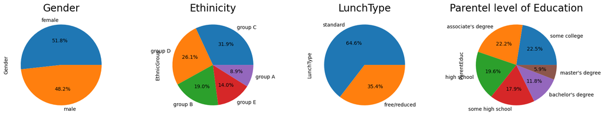

```python
plt.figure(figsize=(20,10))
plt.subplots_adjust(left=0.125, bottom=0.1, right=0.9, top=0.9,
                      wspace=0.5, hspace=0.2)
#Subplots are a way to divide a figure into multiple smaller plots
plt.subplot(141)
plt.title('Gender',fontsize = 20)
student_frame['Gender'].value_counts().plot.pie(autopct="%1.1f%%")

plt.subplot(142)
plt.title('Ethinicity',fontsize = 20)
student_frame['EthnicGroup'].value_counts().plot.pie(autopct="%1.1f%%")

plt.subplot(143)
plt.title('LunchType',fontsize = 20)
student_frame['LunchType'].value_counts().plot.pie(autopct="%1.1f%%")

plt.subplot(144)
plt.title('Parentel level of Education',fontsize = 20)
student_frame['ParentEduc'].value_counts().plot.pie(autopct="%1.1f%%")
plt.show()

#Refference
url='https://www.kaggle.com/code/amulyamanne/eda-on-students-performance-in-exams/notebook'
```

# Observations:

The proportion of male and female are almost same

Highest number of students belong to Group C ethinicity followed by Group D

Highest proportion of the students have standard lunch

Highest proportion of parentel level of Education is 'Some college', 'associate's degreee' and 'high school'

# 2) violinplot:

The violin plots in the code you provided offer a visualization of the distribution of scores for Math, Reading, and Writing subjects in the dataset. They provide insights into the shape, central tendency, and density of the score distributions

- Width: The width of the violin at a specific point represents the density or frequency of scores at that value. A wider section indicates a higher density of scores, while a narrower section indicates a lower density.
- Median: The white dot or line

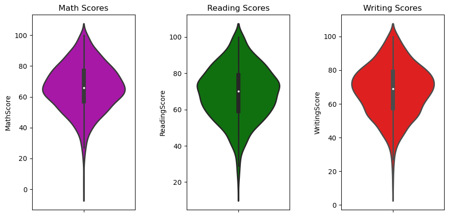

```python
plt.figure(figsize=(15,5))
plt.subplots_adjust(left=0.125, bottom=0.1, right=0.9, top=0.9,
                      wspace=0.5, hspace=0.2)
plt.subplot(141)
plt.title('Math Scores')
sns.violinplot(y='MathScore',data=student_frame,color='m',linewidth=2)
plt.subplot(142)
plt.title('Reading Scores')
sns.violinplot(y='ReadingScore',data=student_frame,color='g',linewidth=2)
plt.subplot(143)
plt.title('Writing Scores')
sns.violinplot(y='WritingScore',data=student_frame,color='r',linewidth=2)
plt.show()

#Refference
url='https://www.kaggle.com/code/amulyamanne/eda-on-students-performance-in-exams/notebook'
```

From the above plots, we can see that the maximum number of students have scored 60-80 in all three subjects i.e., math, reading and writing.

# 3) Boxplot(Scors ,LunchType,TestPrep):

The code you provided generates box plots to visualize the relationship between the(ReadingScore, WritingScore, MathScore) and LunchType, with an additional differentiation based on TestPrep.

The box plots are created separately for each combination of TestPrep and Gender. The LunchType is represented on the x-axis, and the (ReadingScore, WritingScore, and MathScore) are displayed on the y-axis. The boxes in the plot represent the interquartile range (IQR), with the median marked as a line inside the box. Any points outside this range are considered outliers and displayed as individual dots.

By using different colors for each gender, the plots show how the distribution of (ReadingScore, WritingScore, and MathScore) varies across different LunchTypes, taking into account the TestPrep variable.

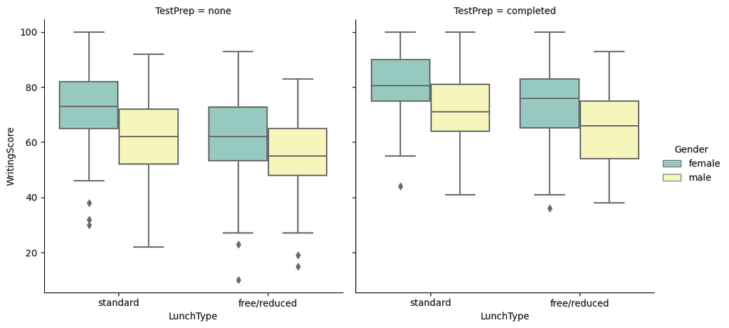

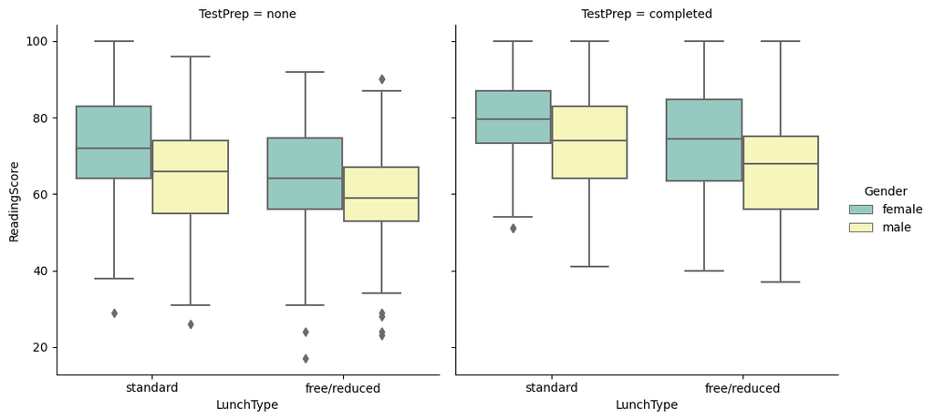

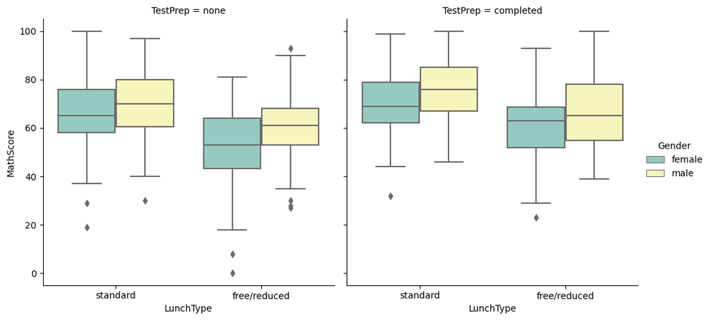

```python
plt.figure(figsize=(8,7))
sns.catplot(y="WritingScore", x="LunchType", hue="Gender",col='TestPrep',kind='box',
data=student_frame, palette="Set3")

plt.figure(figsize=(8,7))
sns.catplot(y="ReadingScore", x="LunchType", hue="Gender",col='TestPrep',kind='box',
data=student_frame, palette="Set3")

plt.figure(figsize=(8,7))
sns.catplot(y="MathScore", x="LunchType", hue="Gender",col='TestPrep',kind='box',
data=student_frame, palette="Set3")
```

Analyzing the box plots can provide insights into the relationship between (WritingScore, ReadingScore, and MathScore) in LunchType and TestPrep. You can observe the following aspects:

We note that female scores are higher than male scores in Reading and Writing, whether they were completed test preparation course or not, and regardless of the lunch type they got. On the other hand, male students score is higher than the female in Math exam.

# 4) Boxplot(Scors ,EthnicGroup,TestPrep):

Let's look at the scores of the students of the different groups who completed test preparation courses.

- `x` and `y`: The variables to be plotted on the x-axis and y-axis, respectively. `y` is set to the score variable (WritingScore, ReadingScore, MathScore), and `x` is set to the categorical variable (EthnicGroup).
- `hue`: This parameter allows you to differentiate the data points or boxes by another categorical variable (Gender in your code). It assigns different colors or patterns to the different levels of the hue variable.

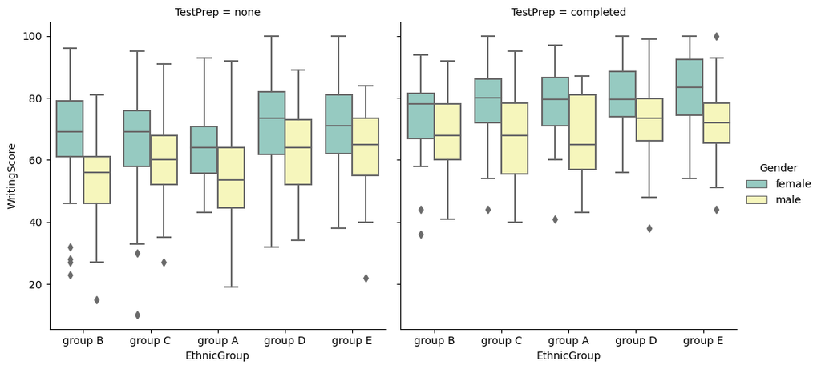

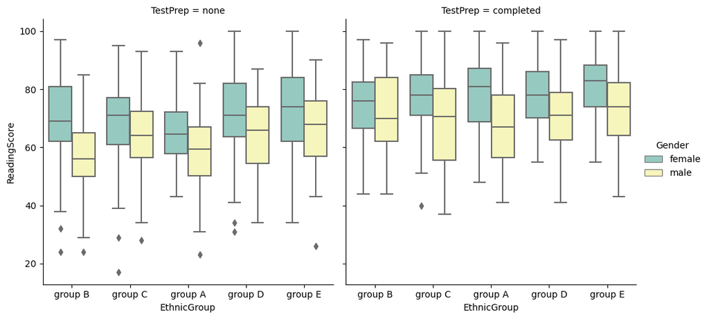

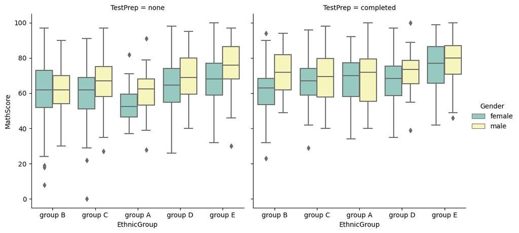

```python
#figure,(axs1,axs2,axs3)= plt.subplots(3,1, figsize=(24,6))

plt.figure(figsize=(8,7))
sns.catplot(y="WritingScore", x="EthnicGroup", hue="Gender",col='TestPrep',kind='box',
data=student_frame, palette="Set3",ax=axs1)

plt.figure(figsize=(8,7))
sns.catplot(y="ReadingScore", x="EthnicGroup", hue="Gender",col='TestPrep',kind='box',
data=student_frame, palette="Set3",ax=axs2)

plt.figure(figsize=(8,7))
sns.catplot(y="MathScore", x="EthnicGroup", hue="Gender",col='TestPrep',kind='box',
data=student_frame, palette="Set3",ax=axs3)
```

# Regression Plots:

```python
slope, intercept, r_value, p_value, std_err
```

[output not shown]

1. slope: The slope represents the rate of change in the dependent variable (y in y = mx + b) with respect to a one-unit change in the independent variable (x)
2. intercept: the value of the dependent variable when the independent variable is zero.
3. r_value: also known as the correlation coefficient or Pearson's correlation coefficient
4. p_value: is a measure of the statistical significance of the estimated relationship between the variables. It indicates the probability of obtaining a relationship as strong as or stronger than the observed relationship by chance alone
5. std_err: The `std_err`, or standard error, quantifies the average amount of variability or dispersion in the observed values around the estimated regression line

```python
#Linear Regression line between MathScore and WritingScore
#We can also specify the confidence interval to use for the linear fit
slope, intercept, r_value, p_value, std_err = stats.linregress(student_frame['WritingScore'],student_frame['MathScore'])
print("y="+str(np.round(slope,2))+"x+"+str(np.round(intercept,2)))
```

```
y=0.8x+11.57
```

```python
#Linear Regression line between ReadingScore and WritingScore
#We can also specify the confidence interval to use for the linear fit
slope, intercept, r_value, p_value, std_err = stats.linregress(student_frame['WritingScore'],student_frame['ReadingScore'])
print("y="+str(np.round(slope,2))+"x+"+str(np.round(intercept,2)))
```

```
y=0.92x+6.75
```

```python
#Linear Regression line between MathScore and ReadingScore
#We can also specify the confidence interval to use for the linear fit
slope, intercept, r_value, p_value, std_err = stats.linregress(student_frame['MathScore'],student_frame['ReadingScore'])
print("y="+str(np.round(slope,2))+"x+"+str(np.round(intercept,2)))
```

```
y=0.79x+17.16
```

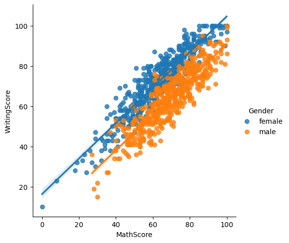

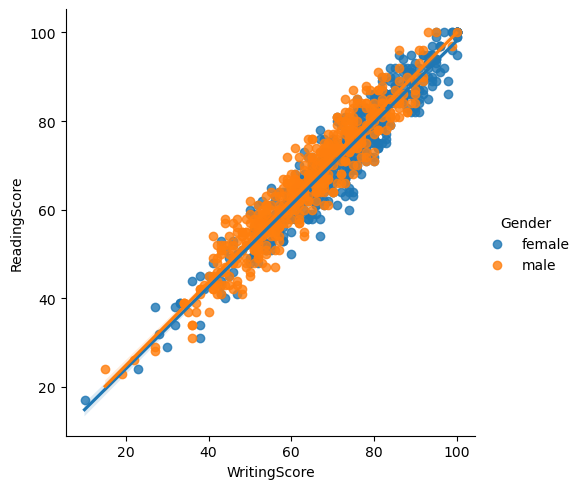

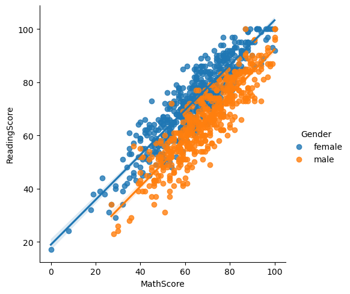

```python
#Linear Regression plots
sns.lmplot(x="MathScore",y= "WritingScore", data=student_frame, hue="Gender",ci=95)
sns.lmplot(x="WritingScore",y= "ReadingScore", data=student_frame, hue="Gender",ci=95)
sns.lmplot(x="MathScore",y= "ReadingScore", data=student_frame, hue="Gender",ci=95)
```

As the regression above manifests, there exist some level of correlation between math score and reading score There exist an extremely strong correlation between reading and writing score.